# Visualisation des résultats : tableaux et graphiques

Laurie Auclair, Jocelyn Lauzon & Sabrina Brisson

10/09/2023

# Importer les données

```r
library(datasets)
data(iris)
```

# Exploration de données

Avant de débuter des analyses, il est important de se familisariser avec son jeu de données afin d’avoir une idée de sa structure. Cette étape permet d’identifier des motifs, des tendances ou des relations préalablement aux tests statistiques, puis de vérifier la qualité des données. Elle permet aussi d’évaluer si les données ont besoin d’être transformées avant de procéder aux analyses.

## Quelques fonctions de base

Pour vérifier le nombre de lignes et de colonnes de votre *dataset*:

```r
dim(iris)
```

```
## [1] 150   5
```

Pour voir les 6 premières lignes du jeu de données:

```r
head(iris)
```

```
##   Sepal.Length Sepal.Width Petal.Length Petal.Width Species
## 1          5.1         3.5          1.4         0.2  setosa
## 2          4.9         3.0          1.4         0.2  setosa
## 3          4.7         3.2          1.3         0.2  setosa
## 4          4.6         3.1          1.5         0.2  setosa
## 5          5.0         3.6          1.4         0.2  setosa
## 6          5.4         3.9          1.7         0.4  setosa
```

Pour connaître le nom des colonnes:

```r
names(iris)
```

```
## [1] "Sepal.Length" "Sepal.Width"  "Petal.Length" "Petal.Width"  "Species"
```

Pour vérifier la classe de chaque variable dans la table de données:

```r
str(iris)
```

```
## 'data.frame':    150 obs. of  5 variables:
##  $ Sepal.Length: num  5.1 4.9 4.7 4.6 5 5.4 4.6 5 4.4 4.9 ...
##  $ Sepal.Width : num  3.5 3 3.2 3.1 3.6 3.9 3.4 3.4 2.9 3.1 ...
##  $ Petal.Length: num  1.4 1.4 1.3 1.5 1.4 1.7 1.4 1.5 1.4 1.5 ...
##  $ Petal.Width : num  0.2 0.2 0.2 0.2 0.2 0.4 0.3 0.2 0.2 0.1 ...
##  $ Species     : Factor w/ 3 levels "setosa","versicolor",..: 1 1 1 1 1 1 1 1 1 1 ...
```

Pour obtenir certaines statistiques descriptives de base, telles que le minimum, le maximum puis la moyenne (variables continues), ainsi que le nombre d’observations (variables catégoriques):

```r
summary(iris)
```

```
##   Sepal.Length    Sepal.Width     Petal.Length    Petal.Width
##  Min.   :4.300   Min.   :2.000   Min.   :1.000   Min.   :0.100
##  1st Qu.:5.100   1st Qu.:2.800   1st Qu.:1.600   1st Qu.:0.300
##  Median :5.800   Median :3.000   Median :4.350   Median :1.300
##  Mean   :5.843   Mean   :3.057   Mean   :3.758   Mean   :1.199
##  3rd Qu.:6.400   3rd Qu.:3.300   3rd Qu.:5.100   3rd Qu.:1.800
##  Max.   :7.900   Max.   :4.400   Max.   :6.900   Max.   :2.500
##        Species
##  setosa    :50
##  versicolor:50
##  virginica :50
##
##
##
```

Pour connaître les niveaux d’une variable catégorique:

```r
levels(iris$Species)
```

```
## [1] "setosa"     "versicolor" "virginica"
```

## Visualisation d’un jeu de données

Une seule matrice de *scatterplots* figure peut être créée avec toutes les variables.

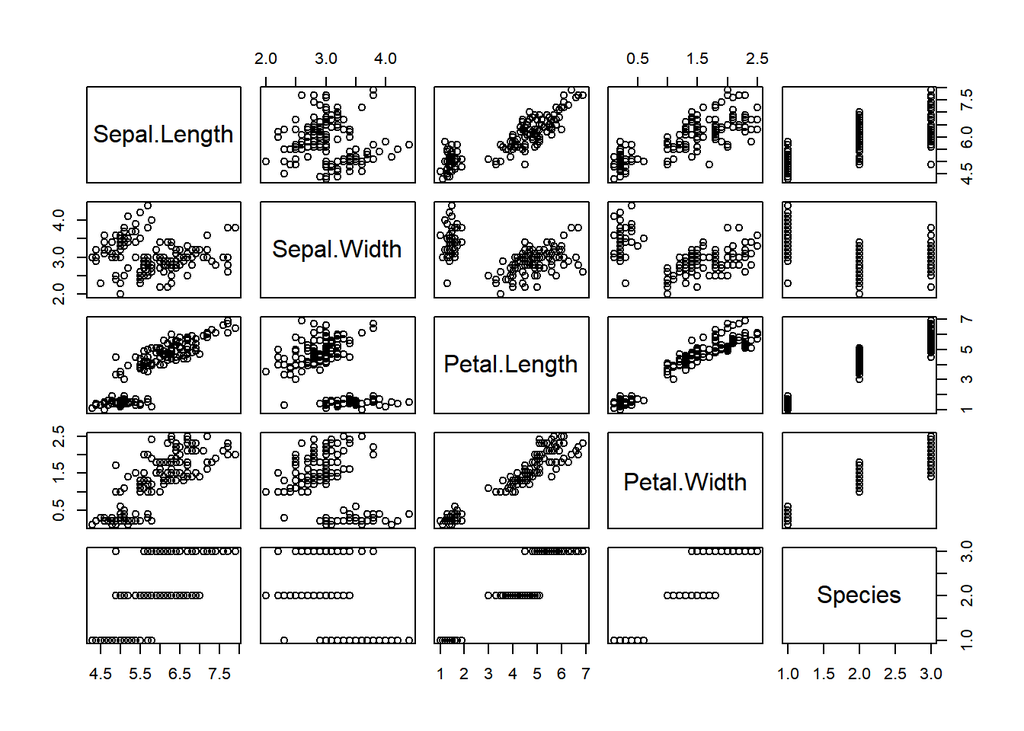

```r
plot(iris)
```

Pour créer un *scatterplot* de la relation entre une variable spécifique et une autre, il suffit d’entrer celles-ci dans la fonction, séparées par le signe **~**. Par exemple, si on veut visualiser la relation entre la longueur des sépales et celle des pétales dans le jeu de données `iris`, on peut l’écrire ainsi:

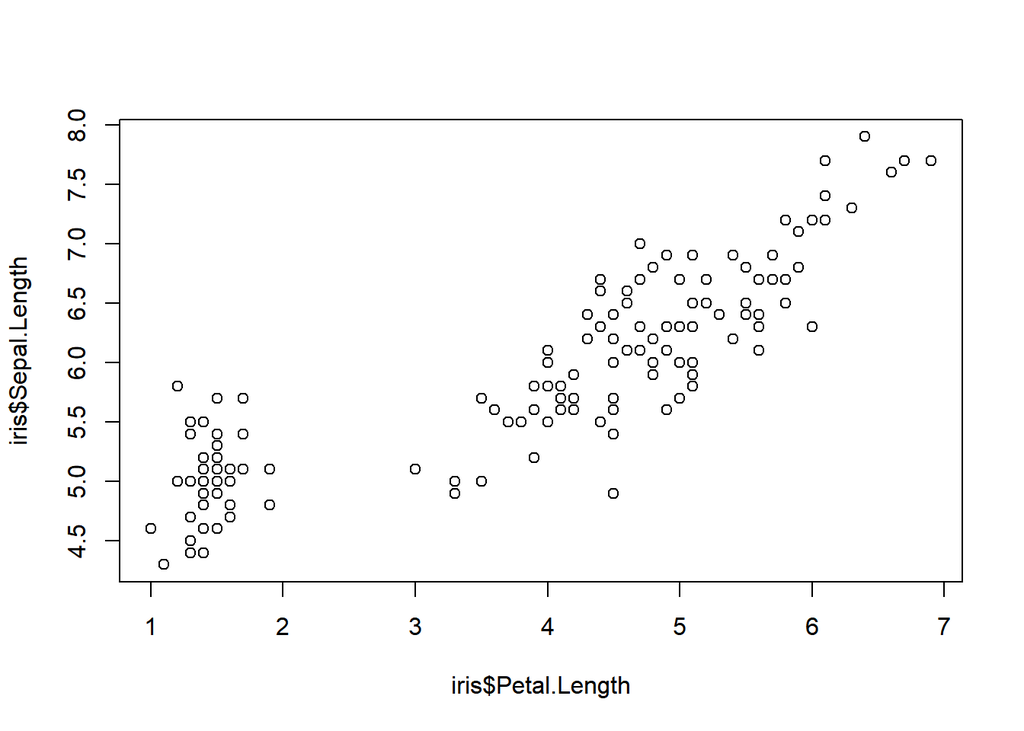

```r
plot(iris$Sepal.Length~iris$Petal.Length)
```

À l’aide de la fonction `boxplot()`, on peut visualiser la dispersion d’une variable selon les groupes d’une variable catégorique. Ce type de figure permet aussi d’identifier rapidement des valeurs aberrantes ou des anomalies.

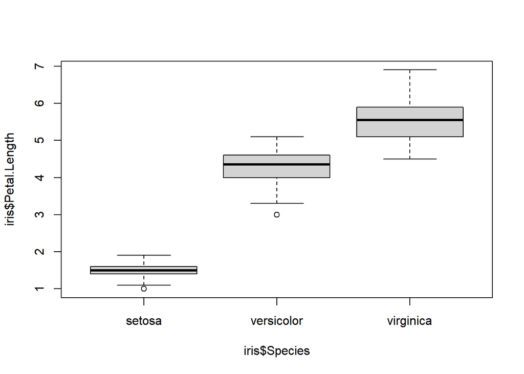

```r
boxplot(iris$Petal.Length~iris$Species)
```

La fonction `hist()` génère un histogramme de la variable qui y est précisée.

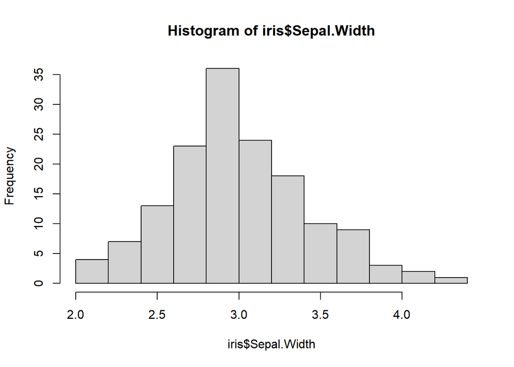

```r
hist(iris$Sepal.Width)
```

# Conseils pour des figures et tableaux réussis

Les figures sont des représentations visuelles des résultats. Elles rendent la lectures des résultats principaux plus facile et permettent de mettre en évidence des tendances ou motifs intéressants. On veut pouvoir la comprendre sans avoir à osciller entre la figure et le texte. Chaque figure devrait correspondre à un message général de votre étude. Chacune devrait répondre en totalité ou en partie à un objectif.

Voici quelques aspects à considérer pour présenter vos figures:

- **Un titre descriptif**: doit contenir les variables mesurées, les unités de mesure, le nom commun et en latin du taxon (si applicable). Le titre doit fournir assez d’information pour qu’on comprenne le contexte de la figure sans devoir se référer au texte.
- **Titre des axes**: doivent comprendre les variables et leur unité de mesure.
- **Les données**: les données brutes (non transformées!) doivent être présentées.
- **Barres d’erreurs, intervalles de confiance et/ou de prédiction**: pour un graphe à barres, ajouter les barres d’erreur afin de représenter la variabilité associée aux données. Pour les figures de régression, il est important d’ajouter l’intervalle de confiance ou de prédiction (dans le cas des résultats d’un modèle linéaire généralisé binomial).
- **Légende dans la figure**: une petite légende peut être nécessaire pour distinguer les traitements (couleur, type de ligne, etc.)
- **Indice de significativité**: on doit retrouver la valeur p d’une relation, des astérisques au-dessus de graphes à barres pour indiquer si la relation est significative, le R2 d’un modèle.

Les tableaux sont un bon choix pour présenter de l’information numérique détaillée. Ils présentent habituellement des résultats plus complexes qui seraient trop encombrants à inclure dans une figure ou dans le texte. Généralement, si les données ne peuvent être présentées en une ou deux phrases, un tableau est nécessaire. Les lignes et les colonnes doivent contenir le nom de la variable ainsi que l’unité de mesure. Un tableau résumé des statistiques peut inclure, par exemple, la moyenne, l’écart-type, les intervalles de confiances, les degrés de liberté, la valeur p et autres statistiques (comme la *F value*).

## Légende d’une figure ou d’un tableau

Les légendes servent à compléter l’information qui est présentée dans le tableau ou la figure. On y retrouve entre autre les tailles d’échantillons (n), valeur p, des descriptions des abréviations, la méthode de collection, le nombre de réplicats, etc.

## Annexe ou pas?

Les données ou les figures qui ne contribuent pas directement à l’histoire principale de votre rapport peuvent être rassemblées en annexes. Dans cette section, on peut retrouver, par exemple, des cartes du site d’échantillonnage, du matériel utilisé pour récolter les données, des tableaux avec davantage d’informations sur les modèles (pas de capture d’écran du *summary*!), etc.

# Coder des graphiques avec ggplot

Avant de commencer, identifiez vos variables dépendantes et indépendantes. Puis, déterminez quels sont les types de ces variables avec lesquelles vous allez travailler.

Sont-elles **catégoriques** (et **Nominales** ou **ordinales**), ou bien **numériques** (et **continues** ou **discrètes**)?

C’est ce qui déterminera le choix de type de figure pour représenter vos données - un histogramme, un scatterplot, un boxplot, un barplot ? Autre?

Consultez ce lien pour mieux comprendre:

https://statisticsbyjim.com/basics/data-types/

```r
summary(iris)
```

```
##   Sepal.Length    Sepal.Width     Petal.Length    Petal.Width
##  Min.   :4.300   Min.   :2.000   Min.   :1.000   Min.   :0.100
##  1st Qu.:5.100   1st Qu.:2.800   1st Qu.:1.600   1st Qu.:0.300
##  Median :5.800   Median :3.000   Median :4.350   Median :1.300
##  Mean   :5.843   Mean   :3.057   Mean   :3.758   Mean   :1.199
##  3rd Qu.:6.400   3rd Qu.:3.300   3rd Qu.:5.100   3rd Qu.:1.800
##  Max.   :7.900   Max.   :4.400   Max.   :6.900   Max.   :2.500
##        Species
##  setosa    :50
##  versicolor:50
##  virginica :50
##
##
##
```

# ANOVA

La fonction de base `plot()` permet de visualiser rapidement un jeu de données, par exemple avec un histogramme. Par contre, vous verrez que son utilisation peut devenir limitée lorsqu’il s’agit de réaliser des figures plus complexes ou simplement modifier certains paramètres graphiques.

C’est pour cela que nous suggérons d’utiliser la fonction `ggplot()`, du package `ggplot2`. Cette fonction permet de réaliser des graphiques de façon plus intuitive et permet de les mettre en page plus facilement qu’avec la fonction `plot()`. Elle est aussi mieux documentée, il est donc plus facile de comprendre et utiliser les différents aspects de la fonction. Google est d’ailleurs votre meilleur allié pour la réalisation de vos figures!

Contrairement à la fonction `plot()`, `ggplot()` fonctionne par couches. Une figure `ggplot()` commence avec la fonction `ggplot()`. Elle sert à “préparer” la figure: on spécifie le jeu de données à utiliser, puis on choisit les variables qui formeront nos axes.

La fonction `ggplot()` nécessite deux arguments: le dataset (jeu de données), puis l’argument `aes()`. Ce dernier nous permet d’assigner des variables du dataset aux composantes du graphique (par exemple, les axes x et y). Voici un exemple, toujours avec le jeu de données Iris. Nous allons tester si la largeur des sépales diffère entre les espèces.

(Revoir l’atelier 3 pour l’explication de l’ANOVA, incluant les postulats et critères d’utilisation, que je passe ici)

```r
library("ggplot2")

head(iris)
```

```
##   Sepal.Length Sepal.Width Petal.Length Petal.Width Species
## 1          5.1         3.5          1.4         0.2  setosa
## 2          4.9         3.0          1.4         0.2  setosa
## 3          4.7         3.2          1.3         0.2  setosa
## 4          4.6         3.1          1.5         0.2  setosa
## 5          5.0         3.6          1.4         0.2  setosa
## 6          5.4         3.9          1.7         0.4  setosa
```

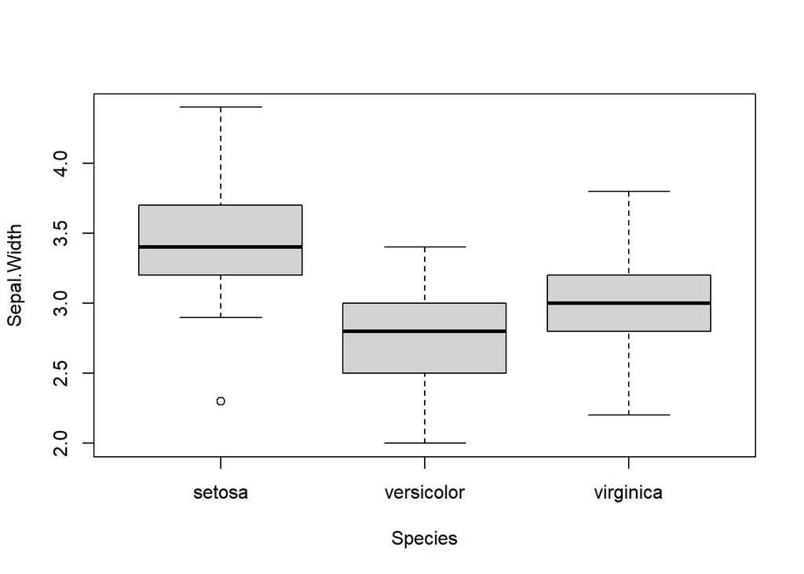

```r
boxplot(Sepal.Width ~ Species,
  data = iris)
```

On produit d’abord le modèle linéaire, et le test d’ANOVA, avec `Sepal.Width` comme variable dépendante et `Species` comme variable indépendante.

```r
modele.SW<-lm(Sepal.Width ~ Species, data = iris)

#Test anova:
anova(modele.SW)
```

```
## Analysis of Variance Table
##
## Response: Sepal.Width
##            Df Sum Sq Mean Sq F value    Pr(>F)
## Species     2 11.345  5.6725   49.16 < 2.2e-16 ***
## Residuals 147 16.962  0.1154
## ---
## Signif. codes:  0 '***' 0.001 '**' 0.01 '*' 0.05 '.' 0.1 ' ' 1
```

```r
summary(modele.SW)
```

```
##
## Call:
## lm(formula = Sepal.Width ~ Species, data = iris)
##
## Residuals:
##    Min     1Q Median     3Q    Max
## -1.128 -0.228  0.026  0.226  0.972
##
## Coefficients:
##                   Estimate Std. Error t value Pr(>|t|)
## (Intercept)        3.42800    0.04804  71.359  < 2e-16 ***
## Speciesversicolor -0.65800    0.06794  -9.685  < 2e-16 ***
## Speciesvirginica  -0.45400    0.06794  -6.683 4.54e-10 ***
## ---
## Signif. codes:  0 '***' 0.001 '**' 0.01 '*' 0.05 '.' 0.1 ' ' 1
##
## Residual standard error: 0.3397 on 147 degrees of freedom
## Multiple R-squared:  0.4008, Adjusted R-squared:  0.3926
## F-statistic: 49.16 on 2 and 147 DF,  p-value: < 2.2e-16
```

Ensuite, on effectue le test post-hoc Tukey:

```r
compSW <- aov(Sepal.Width ~ Species, data = iris)
TukeyHSD(compSW)
```

```
##   Tukey multiple comparisons of means
##     95% family-wise confidence level
##
## Fit: aov(formula = Sepal.Width ~ Species, data = iris)
##
## $Species
##                        diff         lwr        upr     p adj
## versicolor-setosa    -0.658 -0.81885528 -0.4971447 0.0000000
## virginica-setosa     -0.454 -0.61485528 -0.2931447 0.0000000
## virginica-versicolor  0.204  0.04314472  0.3648553 0.0087802
```

```r
summary(compSW)
```

```
##              Df Sum Sq Mean Sq F value Pr(>F)
## Species       2  11.35   5.672   49.16 <2e-16 ***
## Residuals   147  16.96   0.115
## ---
## Signif. codes:  0 '***' 0.001 '**' 0.01 '*' 0.05 '.' 0.1 ' ' 1
```

On peut ensuite construire notre figure. D’abord, la fonction `ggplot()`. On spécifie le jeu de données, puis l’argument `aes()`, ici les axes x et y:

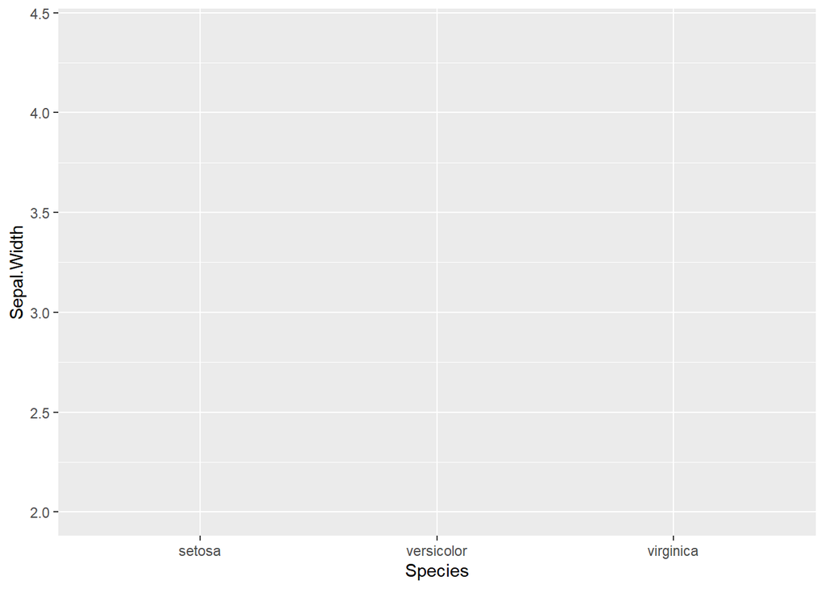

```r
ggplot(iris, aes(x = Species, y = Sepal.Width))
```

Où sont les données? Il faut les ajouter!

C’est comme ça que `ggplot()` fonctionne. On crée la base de notre figure, puis on y ajoute les données à l’aide des fonctions `geom_*`. Par exemple, `geom_points` nous permet d’ajouter des données sous forme de scatterplots (donc des points), tandis que `geom_line` nous permet d’ajouter une ligne. Dans notre cas, nous voulons montrer nos données sous forme de boxplot, donc nous utilisons `geom_boxplot`. Il ne faut pas oublier d’ajouter un `+` après chaque fonction:

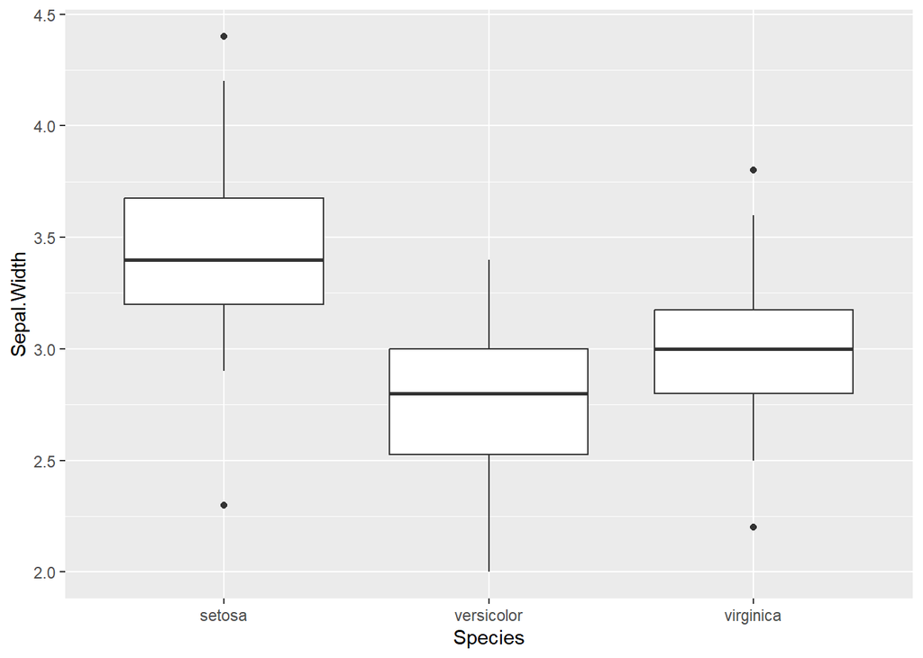

```r
ggplot(iris, aes(x = Species, y = Sepal.Width)) +
geom_boxplot()
```

Pour ajouter/modifier d’autres éléments, il faut ajouter des couches. Ainsi, on peut changer les titres d’axes (labs pour labels), changer le thème de notre graphique (`theme_bw` est plus minimaliste), et avec la fonction `theme()`, retirer la grille et centrer le titre:

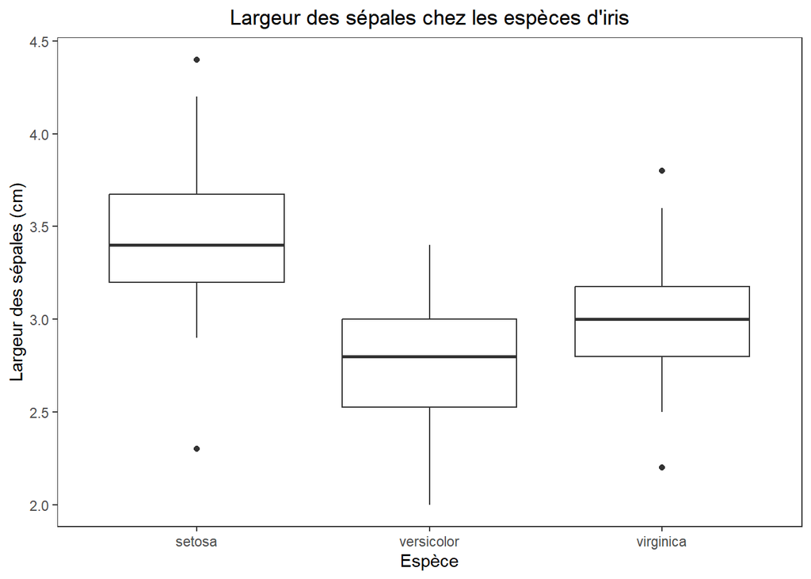

```r
ggplot(iris, aes(x = Species, y = Sepal.Width)) +
geom_boxplot()+
labs(x = "Espèce",
       y = "Largeur des sépales (cm)",
       title = "Largeur des sépales chez les espèces d'iris")+
theme_bw()+
theme(panel.grid.major = element_blank(),
      panel.grid.minor = element_blank(),
      plot.title = element_text(hjust = 0.5))
```

On peut aussi décider de changer les couleurs. Ce n’est pas toujours nécessaire ou pertinent, si ça n’ajoute pas d’information à la figure. Il faut faire attention de ne pas surcharger la figure avec le design esthétique, l’important c’est de focuser sur le message que l’on veut transmettre avec notre figure, et ne pas ajouter d’éléments qui sont distrayants. Mais pour l’exercice et se familiariser avec les paramètres graphiques, essayons:

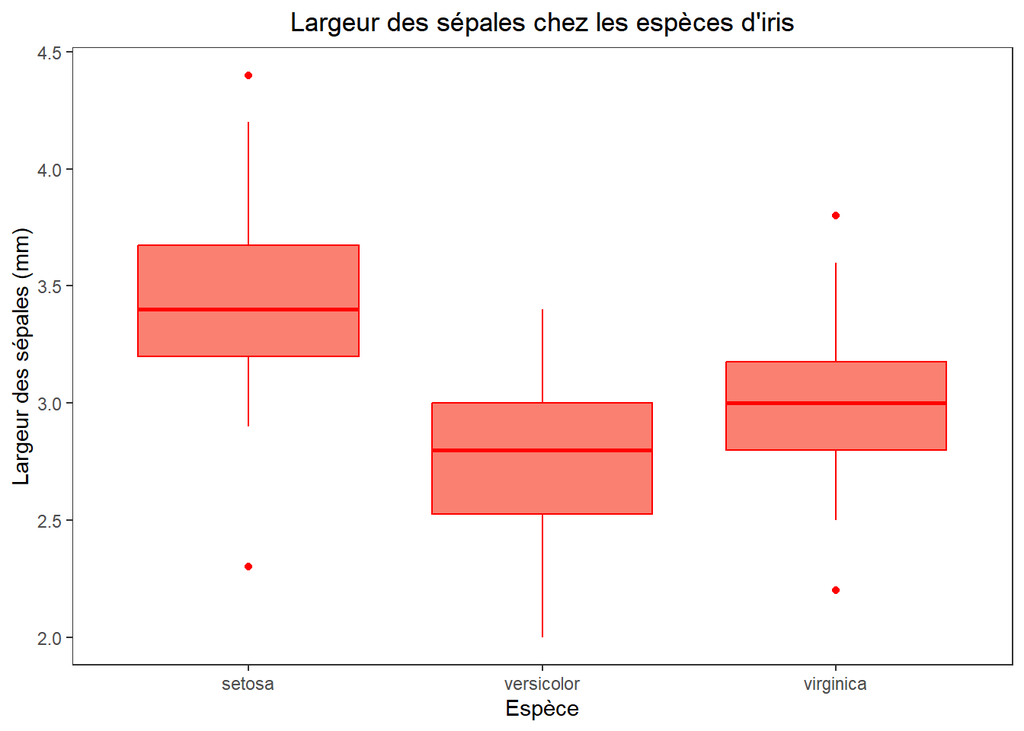

```r
ggplot(iris, aes(x = Species, y = Sepal.Width)) +
geom_boxplot(fill = "salmon",
             color = "red")+
labs(x="Espèce",
     y="Largeur des sépales (mm)",
     title="Largeur des sépales chez les espèces d'iris")+
theme_bw()+
theme(panel.grid.major = element_blank(),
      panel.grid.minor = element_blank(),
      plot.title = element_text(hjust = 0.5))
```

On a donc changé le `fill` (intérieur) et `color` (trait) de nos boxplot, à même la fonction `boxplot()`. On pourrait aussi changer la couleur des boîtes en fonction de l’espèce d’iris (qui est aussi notre variable x). Dans ce cas, il faut ajouter un argument `aes()` à la fonction `boxplot()`, pour assigner notre variable à un aesthetic. Ce sera notre variable `Species`:

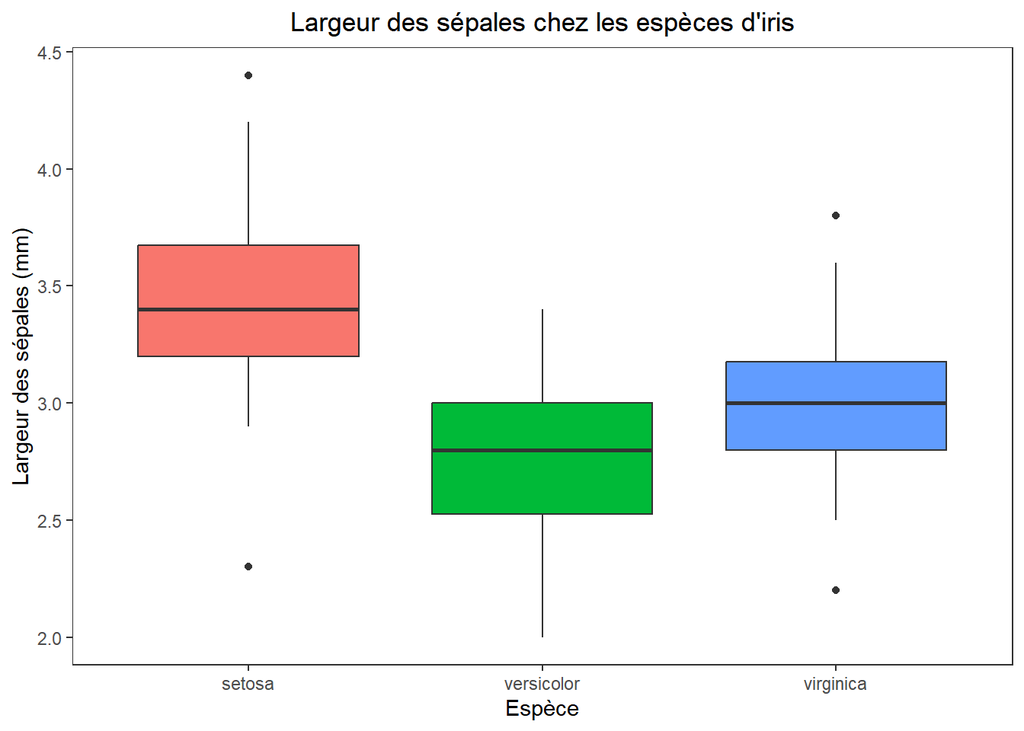

```r
#Fill:

ggplot(iris, aes(x = Species, y = Sepal.Width)) +
geom_boxplot(aes(fill = Species),
             show.legend = FALSE)+
labs(x = "Espèce",
     y = "Largeur des sépales (mm)",
     title = "Largeur des sépales chez les espèces d'iris")+
theme_bw()+
theme(panel.grid.major = element_blank(),
      panel.grid.minor = element_blank(),
      plot.title = element_text(hjust = 0.5))
```

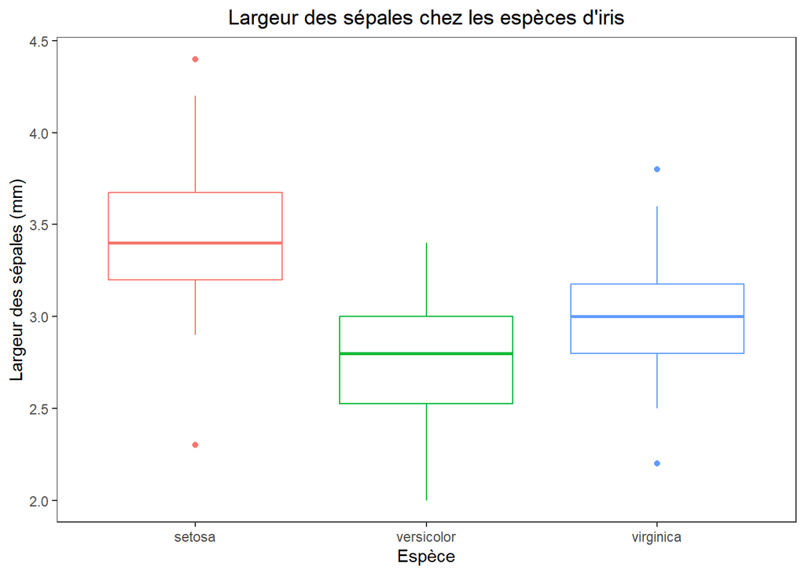

```r
#Color:
ggplot(iris, aes(x = Species, y = Sepal.Width)) +
geom_boxplot(aes(color = Species),
             show.legend = FALSE)+
labs(x = "Espèce",
     y = "Largeur des sépales (mm)",
     title = "Largeur des sépales chez les espèces d'iris")+
theme_bw()+
theme(panel.grid.major = element_blank(),
      panel.grid.minor = element_blank(),
      plot.title = element_text(hjust = 0.5))
```

Il y a aussi des palettes de couleurs prédéfinies dans R, qu’on peut utiliser avec la fonction `scale_fill_brewer` (j’ai choisi la palette “Accent”):

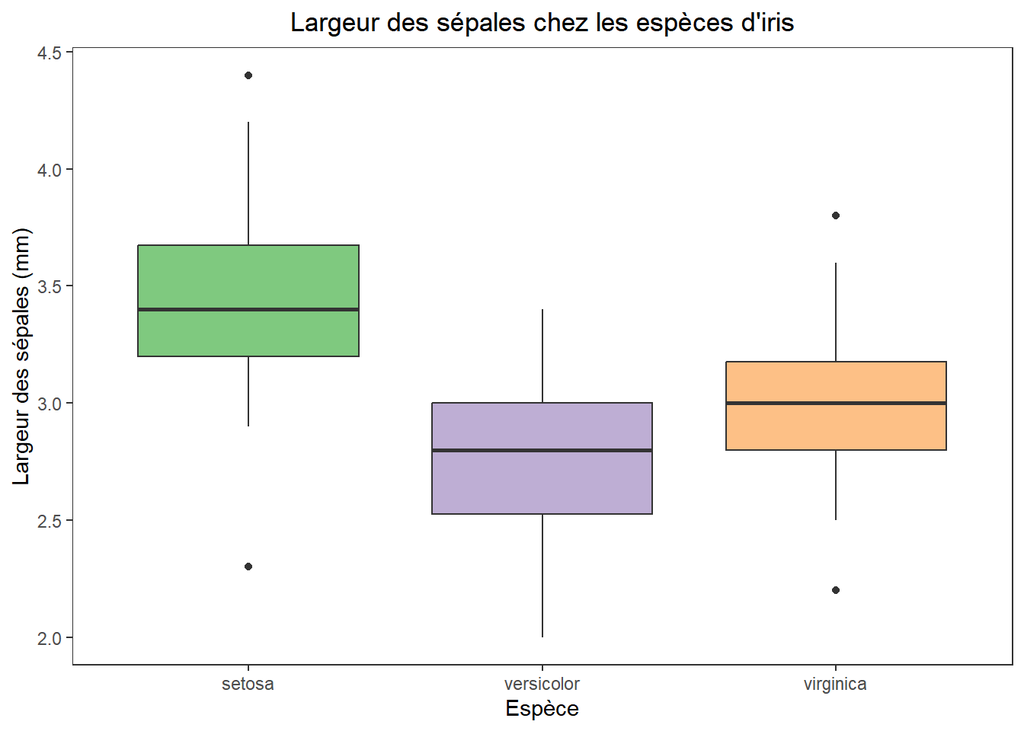

```r
ggplot(iris, aes(x = Species, y = Sepal.Width)) +
geom_boxplot(aes(fill = Species),
             show.legend = FALSE)+
scale_fill_brewer(palette = "Accent")+
labs(x = "Espèce",
     y = "Largeur des sépales (mm)",
     title = "Largeur des sépales chez les espèces d'iris")+
theme_bw()+
theme(panel.grid.major = element_blank(),
      panel.grid.minor = element_blank(),
      plot.title = element_text(hjust = 0.5))
```

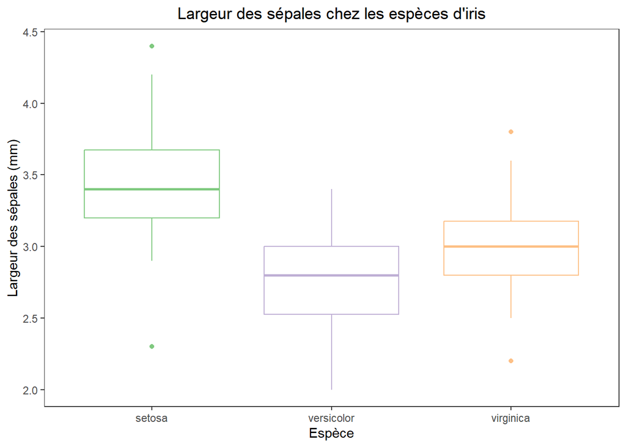

```r
#Qu'est-ce qui arrive si on change Fill pour Color, dans boxplot()? Il faut aussi changer scale_fill_brewer() pour scale_color_brewer():

ggplot(iris, aes(x = Species, y=Sepal.Width)) +
geom_boxplot(aes(color = Species),
             show.legend = FALSE)+
scale_color_brewer(palette = "Accent")+
labs(x = "Espèce",
     y = "Largeur des sépales (mm)",
     title = "Largeur des sépales chez les espèces d'iris")+
theme_bw()+
theme(panel.grid.major = element_blank(),
      panel.grid.minor = element_blank(),
      plot.title = element_text(hjust = 0.5))
```

Puisque `ggplot()` fonctionne par couche, on peut aussi choisir d’ajouter les données brutes à notre figure. Par exemple, on ajoute avant `geom_boxplot()` une autre couche de données avec `geom_point()`, dans lequel on peut spécifier, encore une fois, l’argument `aes()` pour assigner la variable qui sera colorée. L’argument position définit le niveau de “jitter”, c’est-à-dire des points un peu “éparpillés” sur l’axe x. Ensuite, on pourrait ajouter l’argument `alpha=0.5` dans la fonction `boxplot()`, pour les rendre semi-transparents:

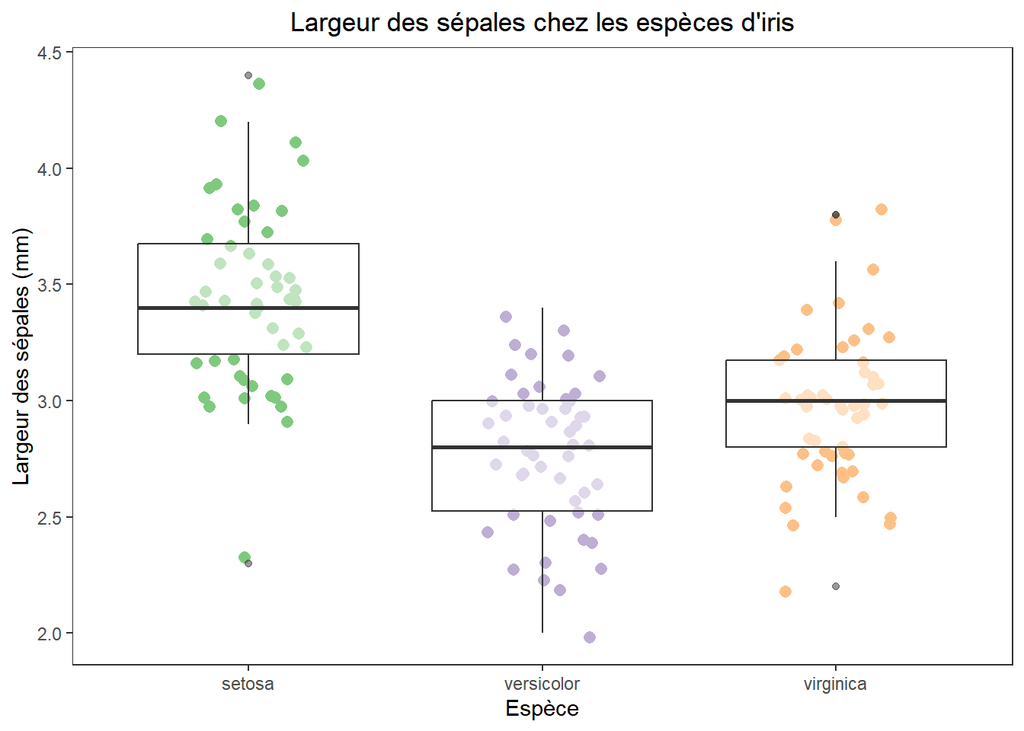

```r
ggplot(iris, aes(x = Species, y = Sepal.Width)) +
geom_point(aes(color = Species),
           position = position_jitter(0.2),
           shape = 16,
           size = 2.5,
           show.legend = FALSE)+
scale_color_brewer(palette = "Accent")+
geom_boxplot(alpha = 0.5)+
labs(x = "Espèce",
     y = "Largeur des sépales (mm)",
     title = "Largeur des sépales chez les espèces d'iris")+
theme_bw()+
theme(panel.grid.major = element_blank(),
      panel.grid.minor = element_blank(),
      plot.title = element_text(hjust = 0.5))
```

On peut aussi ajouter des lettres pour montrer nos résultats de comparaison (voir https://statdoe.com/one-way-anova-and-box-plot-in-r/ pour la méthode). En gros, la fonction `multcompLetters4` assigne les lettres en fonction des groupes du test de Tukey, puis on constuit une table qui contient ces lettres (`LettresSW` dans l’exemple), la variable `Species`, ainsi que la position de la lettre (en haut du quartile pour chaque boîte/valeur de `Species`).

Deux nouvelles libraries sont nécessaires.

```r
library(dplyr)
library(multcompView)
compSW <- aov(Sepal.Width ~ Species, data = iris)
tukeySW <- TukeyHSD(compSW)
print(tukeySW)
```

```
##   Tukey multiple comparisons of means
##     95% family-wise confidence level
##
## Fit: aov(formula = Sepal.Width ~ Species, data = iris)
##
## $Species
##                        diff         lwr        upr     p adj
## versicolor-setosa    -0.658 -0.81885528 -0.4971447 0.0000000
## virginica-setosa     -0.454 -0.61485528 -0.2931447 0.0000000
## virginica-versicolor  0.204  0.04314472  0.3648553 0.0087802
```

```r
cld <- multcompLetters4(compSW, tukeySW)

LettresSW <- group_by(iris, Species) %>%
  summarise(mean = mean(Sepal.Width), quant = quantile(Sepal.Width, probs = 0.75)) %>%
  arrange(desc(mean))

cld <- as.data.frame.list(cld$Species)
LettresSW$cld <- cld$Letters

print(LettresSW)
```

```
## # A tibble: 3 × 4
##   Species     mean quant cld
##   <fct>      <dbl> <dbl> <chr>
## 1 setosa      3.43  3.68 a
## 2 virginica   2.97  3.18 b
## 3 versicolor  2.77  3    c
```

On ajoute nos lettres au boxplot avec la fonction `geom_text()`, avec comme argument `aes()` la table que l’on vient de créer. On peut aussi ajouter la statistique de test avec la fonction `annotate()`, en utilisant les coordonnées x et y dans notre figure.

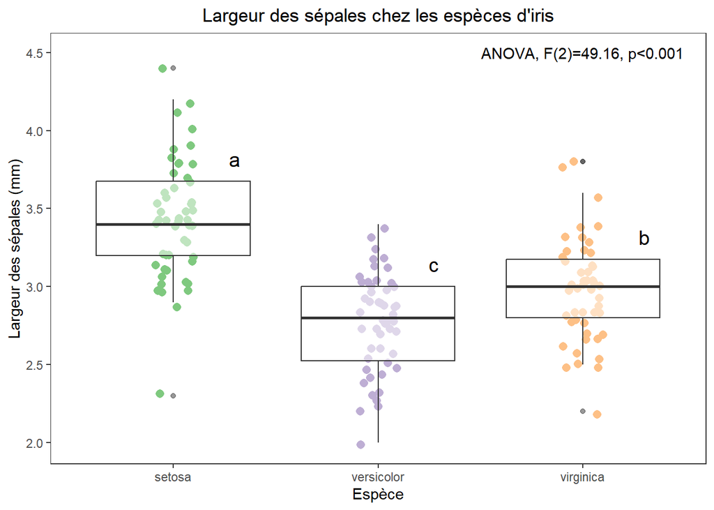

```r
ggplot(iris, aes(x = Species, y = Sepal.Width)) +
geom_point(aes(color = Species),
           position = position_jitter(0.1),
           shape = 16,
           size = 2.5,
           show.legend = FALSE)+
scale_color_brewer(palette = "Accent")+
geom_boxplot(alpha = 0.5)+
labs(x = "Espèce",
     y = "Largeur des sépales (mm)",
     title = "Largeur des sépales chez les espèces d'iris")+
theme_bw()+
theme(panel.grid.major = element_blank(),
      panel.grid.minor = element_blank(),
      plot.title = element_text(hjust = 0.5))+
geom_text(data = LettresSW,
          aes(x = Species, y = quant, label = cld),
          size = 5,
          vjust=-1, hjust =-5)+
annotate("text", x = 3, y = 4.5, label = "ANOVA, F(2)=49.16, p<0.001")
```

Pour bien faire, on pourrait même changer les étiquettes en x. Avec la fonction `scale_x_discrete`, j’ajoute “I.” pour iris à chaque étiquette et je les mets en italique, puisque ce sont des noms latins, avec l’argument `axis.text.x` dans la fonction `theme()`.

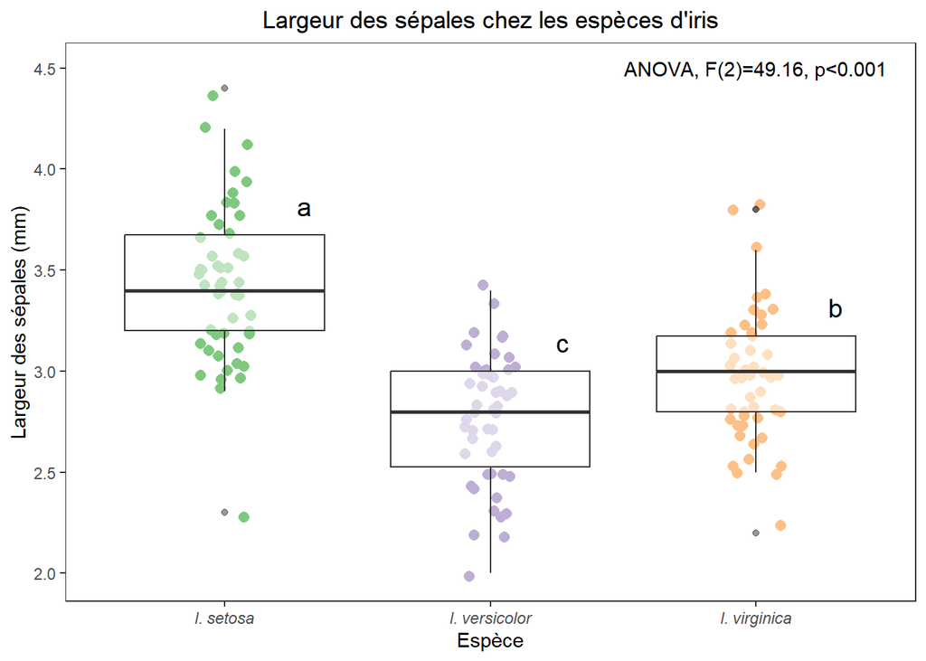

```r
ggplot(iris, aes(x = Species, y = Sepal.Width)) +
geom_point(aes(color = Species),
           position = position_jitter(0.1),
           shape = 16,
           size = 2.5, show.legend = FALSE)+
scale_color_brewer(palette = "Accent")+
geom_boxplot(alpha = 0.5)+
labs(x = "Espèce",
     y = "Largeur des sépales (mm)",
     title = "Largeur des sépales chez les espèces d'iris")+
theme_bw()+
theme(panel.grid.major = element_blank(),
      panel.grid.minor = element_blank(),
      plot.title = element_text(hjust = 0.5),
      axis.text.x = element_text(face="italic"))+
geom_text(data = LettresSW,
          aes(x = Species, y = quant, label = cld),
          size = 5,
          vjust=-1, hjust =-5)+
annotate("text", x = 3, y = 4.5, label = "ANOVA, F(2)=49.16, p<0.001")+
scale_x_discrete(labels = c("I. setosa", "I. versicolor", "I. virginica"))
```

# GLM

Essayons avec un type d’analyse différent, les GLM binomiaux. Nous allons utiliser le jeu de données “survie”. Encore une fois, référez-vous à l’atelier sur les modèles GLM pour bien comprendre les analyses, j’y vais plus grossièrement ici.

Nous aurons besoin de:

```r
library(ggeffects)
```

D’abord, télécharger le jeu de données “survie.csv”, puis l’ouvrir dans R (*le jeu provient du cours BIO8092).

```r
surv <- read.delim2('survie.csv', header = TRUE, sep = ';', dec = '.')
head(surv)
```

```
##       masse      age sex survie
## 1 103.31373 60.43044   0      1
## 2 100.38447 63.11296   1      1
## 3 101.89734 60.85186   1      1
## 4  98.54894 62.10991   0      0
## 5 101.82275 59.57312   0      1
## 6 102.47745 56.40091   1      1
```

On a donc des données de masse, d’âge et de sexe (sous forme 0/1, mâle=1 et femelle=0), ainsi que ce qui sera notre variable réponse, la survie d’une bibitte quelconque. Celle-ci est aussi notée 0/1, car évidemment, c’est une variable binaire. Puisque celle-ci ne suit pas une loi normale, nous devons utiliser un GLM.

Prenez bien le temps de comprendre comment fonctionne la régression logistique. L’interprétation des coefficients n’est pas aussi directe ou intuitive que pour la régression linéaire. Comme vous vous souvenez sûrement, les paramètres sont dans une échelle différente que l’échelle de la “réalité”: la pente nous donne plutôt le changement dans le logit de la probabilité, pour un changement d’une unité de la variable explicative.

Rappel: Les GLM fonctionnent avec ce qu’on appelle une fonction de lien (“logit”, dans le cas d’une variable binaire - il en existe d’autre pour les autres distributions, comme celle de poisson ou gamma). Cette transformatiom permet de passer de l’échelle des valeurs observées (soit 0 et 1), à une échelle qui est linéaire, qui nous permet de “linéariser” un modèle à variable réponse binaire. Ainsi: Les valeurs observées de y (0 et 1) sont transformées avec la fonction de lien f() pour être sur la même échelle que le prédicteur linéaire (a+bxi). Les paramètres du modèle, nécessairement, sont dans cette échelle transformée. C’est pour cela qu’on ne peut pas calculer directement les valeurs prédites, comme avec la régression linéaire. Plutôt, les valeurs prédites par le modèle sont obtenues en appliquant l’inverse de la transformation, donc l’inverse de la fonction de lien (f−1), au prédicteur linéaire. Ainsi, Probabilité(succès)= logit−1(a+bx).

En gros,

Si le ratio des cotes est >1, la probabilité de succès (dans notre cas, la survie) augmente avec l’augmentation de notre variable dépendante.

Si le ratio des cotes est <1, la probabilité de succès (dans notre cas, la survie) diminue avec l’augmentation de notre variable dépendante.

Mais ce qui vous intéresse dans le cadre de cet atelier, c’est de visualiser les effets desdites variables!

Pour simplifier les calculs, on peut utiliser la fonction `ggpredict()` du package `ggeffects`. Celle-ci nous calcule les probabilités de survie (ou de succès) ainsi qu’un intervalle de confiance. On peut ensuite utiliser ces probabilités pour réaliser une figure avec `ggplot()`.

Reprenons notre jeu de données.

```r
head(surv)
```

```
##       masse      age sex survie
## 1 103.31373 60.43044   0      1
## 2 100.38447 63.11296   1      1
## 3 101.89734 60.85186   1      1
## 4  98.54894 62.10991   0      0
## 5 101.82275 59.57312   0      1
## 6 102.47745 56.40091   1      1
```

On peut commencer avec la question suivante: *quel est l’effet de la masse sur la probabilité de survie?*

Pour faire notre modèle, on utilise la fonction `glm`, qui ressemble à la fonction `lm` que nous avons utilisée plus tôt. Avec `glm`, on ajoute l’argument `family = binomial`, qui spécifie la distribution avec laquelle nous travaillons, soit la distribution binomiale.

```r
modele.masse <- with(surv, glm(survie ~ masse, family = binomial))

summary(modele.masse)
```

```
##
## Call:
## glm(formula = survie ~ masse, family = binomial)
##
## Coefficients:
##             Estimate Std. Error z value Pr(>|z|)
## (Intercept) -45.9643    21.0574  -2.183   0.0290 *
## masse         0.4726     0.2095   2.256   0.0241 *
## ---
## Signif. codes:  0 '***' 0.001 '**' 0.01 '*' 0.05 '.' 0.1 ' ' 1
##
## (Dispersion parameter for binomial family taken to be 1)
##
##     Null deviance: 39.880  on 47  degrees of freedom
## Residual deviance: 34.075  on 46  degrees of freedom
## AIC: 38.075
##
## Number of Fisher Scoring iterations: 5
```

```r
#Quel serait le ratio des cotes?

b.masse<-modele.masse$coefficients['masse']

exp(b.masse)
```

```
##    masse
## 1.604189
```

La masse aurait donc un effet positif sur la probabilité de survie. Essayons de visualiser ce résultat.

J’utilise la fonction `ggpredict` du package `ggeffects`. On spéficie d’abord le modèle à prédire, ensuite la variable que l’on souhaite visualiser en x.

```r
predictions.masse<-ggpredict(modele.masse, "masse")
```

```
## Data were 'prettified'. Consider using `terms="masse [all]"` to get
##   smooth plots.
```

```r
predictions.masse
```

```
## # Predicted probabilities of survie
##
## masse | Predicted |       95% CI
## --------------------------------
##    96 |      0.36 | [0.07, 0.81]
##    97 |      0.47 | [0.14, 0.83]
##    99 |      0.70 | [0.44, 0.87]
##   100 |      0.79 | [0.60, 0.90]
##   101 |      0.85 | [0.71, 0.93]
##   102 |      0.90 | [0.76, 0.96]
##   103 |      0.94 | [0.80, 0.98]
##   106 |      0.98 | [0.85, 1.00]
```

```
##
## Not all rows are shown in the ouput. Use `print(..., n = Inf)` to show
##   all rows.
```

Dans le récapitulatif, on voit l’étendue des valeurs de masse, ainsi que la probabilité de survie prédite pour chaque valeur de masse. De plus, un intervalle de confiance à 95% a été calculé. On a donc ce qu’il faut pour réaliser notre figure.

Nous utiliserons comme source de données, la table de prédictions que nous venons de sortir.

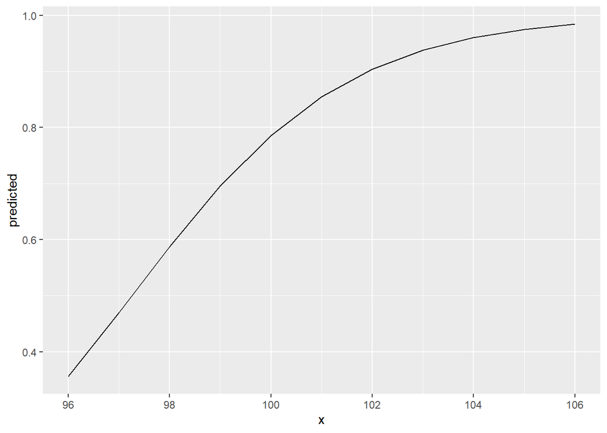

```r
plot.masse <- ggplot()+
geom_line(data = predictions.masse,
          aes(x = x, y = predicted))

plot.masse
```

On voit que la valeur maximale de l’axe y est de 1, qui correspondrait à une probabilité de 100%. Il est important d’ajouter notre invervalle de confiance, avec `geom_ribbon`. On utilise à nouveau notre table de prédictions, puisqu’elle contient les intervalles de confiance. Avec `aes(ymin = conf.low, ymax = conf.high)`, on délimite les limites haut et bas de notre ruban. Ces limites correspondent aux valeurs d’intervalle calculées. Avec `alpha = .2`, le ruban est plus translucide:

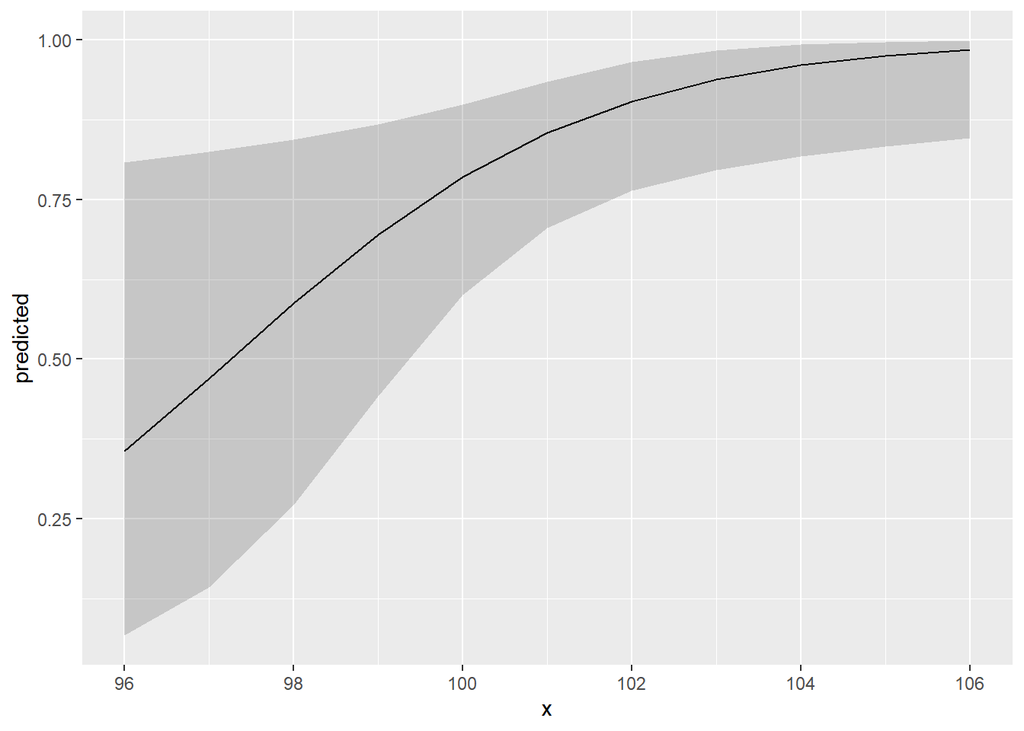

```r
plot.masse <- ggplot()+
geom_line(data = predictions.masse,
          aes(x = x, y = predicted))+
geom_ribbon(data = predictions.masse,
            show.legend = FALSE,
            aes(x = x, y = predicted, ymin = conf.low, ymax = conf.high),
            alpha = .2)

plot.masse
```

C’est bien, mais notre figure est pas mal tout nue!

On peut identifier nos axes + titre, ajouter le `theme_bw()`, enlever la grille + centrer le titre:

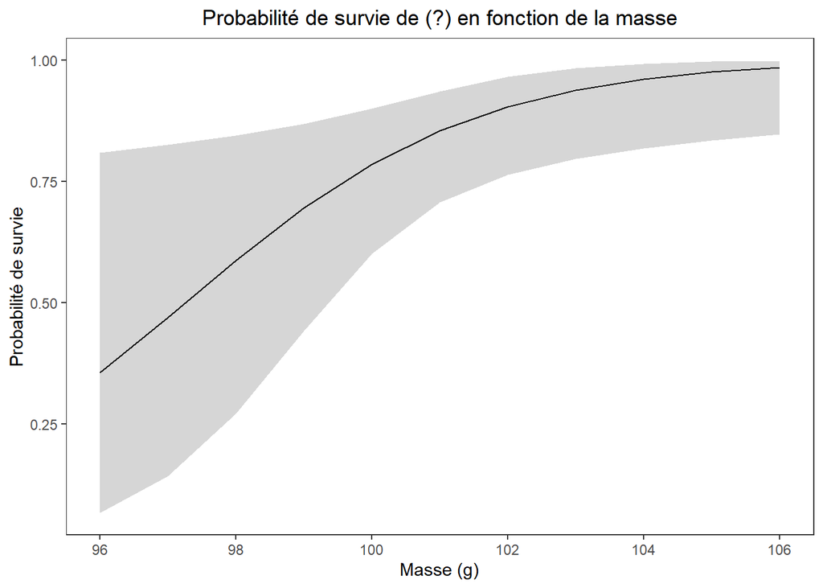

```r
plot.masse <- ggplot()+
geom_line(data = predictions.masse,
          aes(x = x, y = predicted))+
geom_ribbon(data = predictions.masse,
            show.legend = FALSE,
            aes(x = x, y = predicted, ymin = conf.low, ymax = conf.high),
            alpha = .2)+
labs(x = "Masse (g)",
     y = "Probabilité de survie",
     title = "Probabilité de survie de (?) en fonction de la masse")+
theme_bw()+
theme(panel.grid.major = element_blank(),
      panel.grid.minor = element_blank(),
      plot.title = element_text(hjust = 0.5))

plot.masse
```

Les valeurs de notre axe y sont de 0 à 1. On peut transformer notre axe pour qu’il soit exprimé en % sur 100, avec `scale_y_continuous`. De plus, `ggplot()` a choisi de commencer notre axe un peu en haut de zéro (même si c’est moins évident sur cette figure - retournez voir celle sans le ruban) car il optimise l’espace que prend nos données sur le graphique. Il serait plus juste de commencer notre axe à zéro. J’ajoute l’argument `limits = c(0, 1)` dans `scale_y_continuous`.

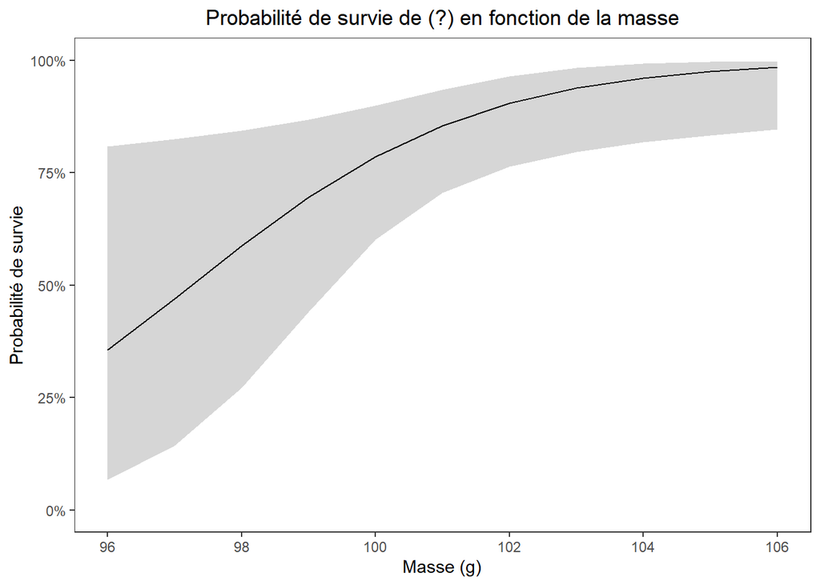

```r
plot.masse <- ggplot()+
geom_line(data = predictions.masse,
          aes(x = x, y = predicted))+
geom_ribbon(data = predictions.masse,
            show.legend = FALSE,
            aes(x = x, y = predicted, ymin = conf.low, ymax = conf.high),
            alpha = .2)+
labs(x = "Masse (g)",
     y = "Probabilité de survie",
     title = "Probabilité de survie de (?) en fonction de la masse")+
theme_bw()+
theme(panel.grid.major = element_blank(),
      panel.grid.minor = element_blank(),
      plot.title = element_text(hjust = 0.5))+
scale_y_continuous(labels = scales::percent,
                   limits = c(0, 1))

plot.masse
```

Si on voulait avoir moins de ticks sur l’axe des y (peut rendre la figure plus facilement lisible si elle est en petit format), on peut ajouter `breaks = seq(0, 1, by = 0.5)` dans `scale_y_continuous`, pour que les ticks soient à intervalle de 0.5:

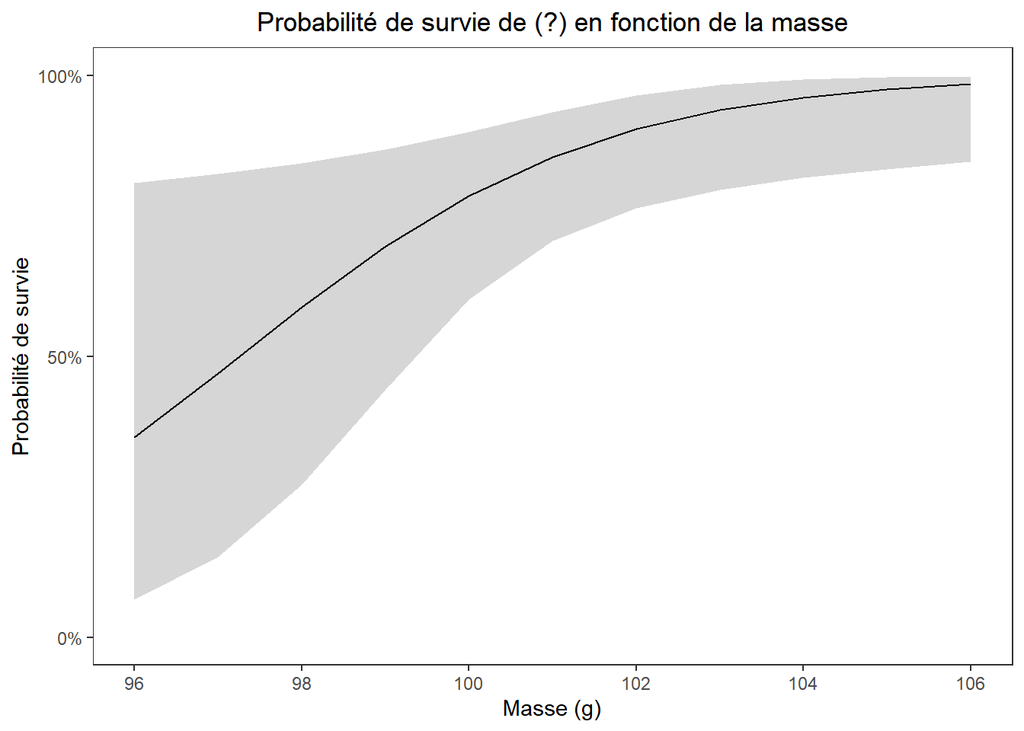

```r
plot.masse <- ggplot()+
geom_line(data = predictions.masse,
          aes(x = x, y = predicted))+
geom_ribbon(data = predictions.masse,
            show.legend = FALSE,
            aes(x = x, y = predicted, ymin = conf.low, ymax = conf.high),
            alpha = .2)+
labs(x = "Masse (g)",
     y = "Probabilité de survie",
     title = "Probabilité de survie de (?) en fonction de la masse")+
theme_bw()+
theme(panel.grid.major = element_blank(),
      panel.grid.minor = element_blank(),
      plot.title = element_text(hjust = 0.5))+
scale_y_continuous(labels = scales::percent,
                   limits = c(0, 1),
                   breaks = seq(0, 1, by = 0.5))

plot.masse
```

Terminons la figure avec une jolie couleur, tiens: Dans `geom_line()`, j’ajoute `color=group` à l’argument `aes()`. On indique ainsi que le paramètre graphique de la couleur du trait sera associée aux “groupes”. Pour l’instant, on n’a qu’un seul groupe, donc ça peut sembler abstrait. Par contre, c’est ce qui nous permet, avec `scale_color_manual()`, de changer la couleur de notre ligne.

Même chose pour le ruban: dans `geom_ribbon()`, j’ajoute `fill=group` à l’argument `aes()`, pour assigner le remplissage du ruban aux “groupes”.

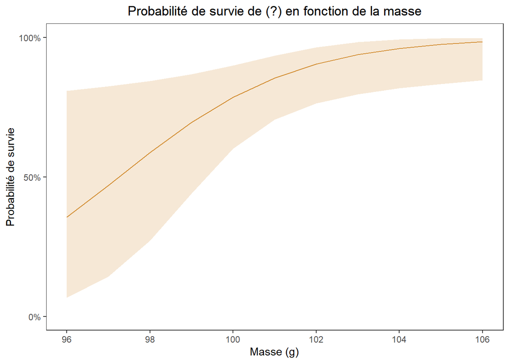

```r
plot.masse <- ggplot()+
geom_line(data = predictions.masse,
          aes(x = x, y = predicted, color = group),
          show.legend = FALSE)+
scale_color_manual(values = c("#D28D32"))+
geom_ribbon(data = predictions.masse,
            show.legend = FALSE,
            aes(x = x, y = predicted, fill = group, ymin = conf.low, ymax = conf.high),
            alpha = .2)+
scale_fill_manual(values = c("#D28D32"))+
labs(x = "Masse (g)",
     y = "Probabilité de survie",
     title = "Probabilité de survie de (?) en fonction de la masse")+
theme_bw()+
theme(panel.grid.major = element_blank(),
      panel.grid.minor = element_blank(),
      plot.title = element_text(hjust = 0.5))+
scale_y_continuous(labels = scales::percent,
                   limits = c(0, 1),
                   breaks = seq(0, 1, by = 0.5))

plot.masse
```

Remarquez que j’utilise `color` pour la ligne, et `fill` pour le ruban, comme nous avions abordé plus tôt avec les points dans l’ANOVA. En effet, on ne peut pas “fill” une ligne; en revanche, on peut “color” un ruban… Mais c’est sa bordure qui sera colorée:

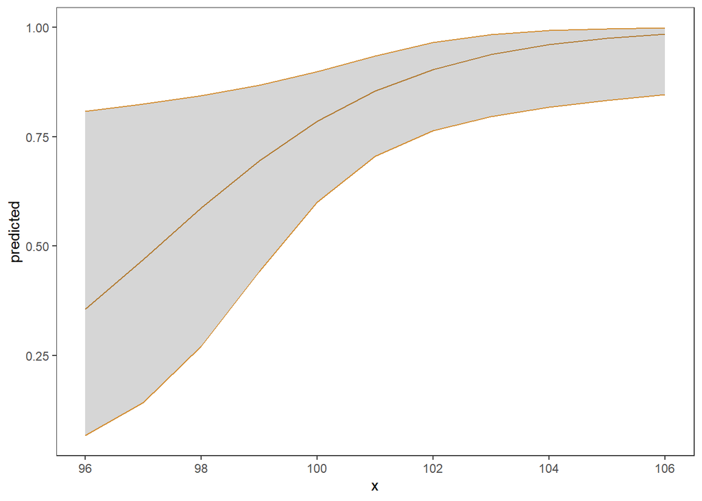

```r
plot.masse <- ggplot()+
geom_line(data = predictions.masse,
          aes(x = x, y = predicted, color = group),
          show.legend = FALSE)+
scale_color_manual(values = c("#D28D32"))+
geom_ribbon(data = predictions.masse,
            show.legend = FALSE,
            aes(x = x, y = predicted, color = group, ymin = conf.low, ymax = conf.high),
            alpha = .2)+
theme_bw()+
theme(panel.grid.major = element_blank(),
      panel.grid.minor = element_blank(),
      plot.title = element_text(hjust = 0.5))

plot.masse
```

On pourrait aussi ajouter une couche de données contenant les données brutes, avec `geom_point`. Toutefois, on souhaite afficher les données brutes issues de `surv`, et non les résultats de notre modèle `predictions.masse`. Donc comme avec notre ANOVA, on assigne nos `aes()` dans `geom_point(data=surv, aes(x=masse, y=survie))`. J’utilise `position = position_jitter()`, car cela permet de mieux voir les points qui sont collés tous à la même valeur, soit 0 et 1 (aussi, détail, mais pour cette figure, je dois aussi ajouter `height = 0.01` pour réduire le niveau de jitter appliqué en y, sinon le jitter s’énerve un peu trop et remplit tout l’espace - je crois que c’est lié au fait que notre variable n’a que deux valeurs…). De plus, vu que ça fait “déborder” les points un peu en dessous de 0 et un peu au dessus de 1, j’élargis les limites de l’axe y avec `limits = c(-0.02, 1.02))` dans `scale_y_continuous()`.

On termine en changeant la couleur des points et en augmentant la taille du trait avec `linewidth=1.1` dans `geom_line`.

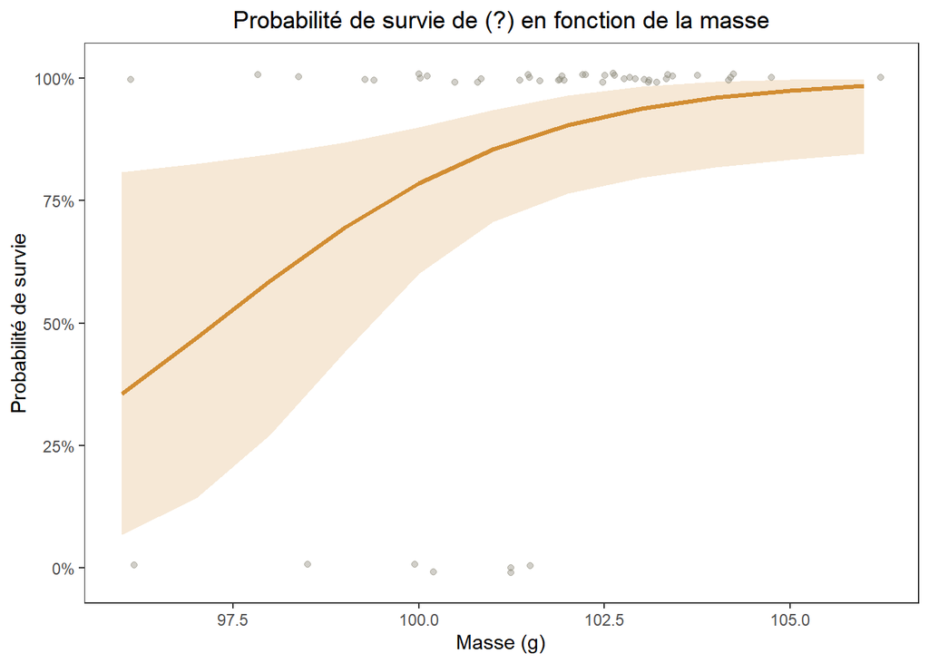

```r
plot.masse <- ggplot()+
geom_line(data = predictions.masse,
          aes(x = x, y = predicted, color = group),
          show.legend = FALSE,
          linewidth = 1.1)+
scale_color_manual(values = c("#D28D32"))+
geom_ribbon(data = predictions.masse,
            show.legend = FALSE,
            aes(x = x, y = predicted, fill = group, ymin = conf.low, ymax = conf.high),
            alpha = .2)+
scale_fill_manual(values = c("#D28D32"))+
geom_point(data = surv,
           aes(x = masse, y = survie),
           alpha = .4,
           color = "cornsilk4",
           position = position_jitter(0.1, height = 0.01))+
labs(x = "Masse (g)",
     y = "Probabilité de survie",
     title = "Probabilité de survie de (?) en fonction de la masse")+
theme_bw()+
theme(panel.grid.major = element_blank(),
      panel.grid.minor = element_blank(),
      plot.title = element_text(hjust = 0.5))+
scale_y_continuous(labels = scales::percent,
                   limits = c(-0.02, 1.02))

plot.masse
```

Dans le jeu de données, on retrouve aussi la variable `sexe`:

```r
head(surv)
```

```
##       masse      age sex survie
## 1 103.31373 60.43044   0      1
## 2 100.38447 63.11296   1      1
## 3 101.89734 60.85186   1      1
## 4  98.54894 62.10991   0      0
## 5 101.82275 59.57312   0      1
## 6 102.47745 56.40091   1      1
```

On pourrait donc faire un deuxième modèle qui inclut l’effet du sexe de la bibitte dans sa probabilité de survie.

```r
modele.masse.sexe <- with(surv, glm(survie ~ masse + sex, family = binomial))
summary(modele.masse.sexe)
```

```
##
## Call:
## glm(formula = survie ~ masse + sex, family = binomial)
##
## Coefficients:
##             Estimate Std. Error z value Pr(>|z|)
## (Intercept) -60.3269    26.0796  -2.313   0.0207 *
## masse         0.6094     0.2574   2.368   0.0179 *
## sex           1.3184     1.0860   1.214   0.2247
## ---
## Signif. codes:  0 '***' 0.001 '**' 0.01 '*' 0.05 '.' 0.1 ' ' 1
##
## (Dispersion parameter for binomial family taken to be 1)
##
##     Null deviance: 39.880  on 47  degrees of freedom
## Residual deviance: 32.401  on 45  degrees of freedom
## AIC: 38.401
##
## Number of Fisher Scoring iterations: 6
```

Il ne semble pas avoir d’effet significatif du sexe sur la probabilité de survie.

**Mais, pour l’exercice, faisons comme si l’effet était significatif et qu’on voulait l’illustrer dans une figure!**

On calcule d’abord nos valeurs prédites de survie:

```r
predictions.masse.sexe.test <- ggpredict(modele.masse.sexe, c("masse"))
```

```
## Data were 'prettified'. Consider using `terms="masse [all]"` to get
##   smooth plots.
```

```r
predictions.masse.sexe.test
```

```
## # Predicted probabilities of survie
##
## masse | Predicted |       95% CI
## --------------------------------
##    96 |      0.24 | [0.03, 0.76]
##    97 |      0.36 | [0.08, 0.78]
##    99 |      0.66 | [0.40, 0.85]
##   100 |      0.78 | [0.59, 0.90]
##   101 |      0.87 | [0.71, 0.95]
##   102 |      0.92 | [0.77, 0.98]
##   103 |      0.96 | [0.80, 0.99]
##   106 |      0.99 | [0.87, 1.00]
##
## Adjusted for:
## * sex = 0.50
```

```
##
## Not all rows are shown in the ouput. Use `print(..., n = Inf)` to show
##   all rows.
```

Remarquez dans le récapitulatif: *Adjusted for: sex = 0.50*

Rappelez-vous comment est construit un modèle GLM:

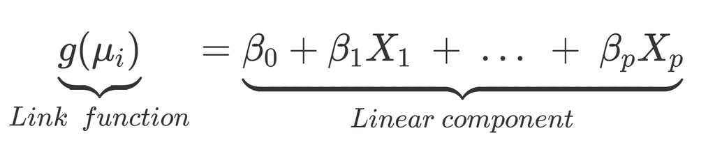

Les différents termes (paramètres β)*(la valeur de x) sont additionnés pour obtenir la variable réponse.

Donc, quand on lui demande de calculer la probabilité de survie en fonction de la masse, la fonction `ggpredit()` utilise par défaut la valeur moyenne de l’autre variable. Il set donc la valeur de `sexe` à 0,5. On obtient comme figure:

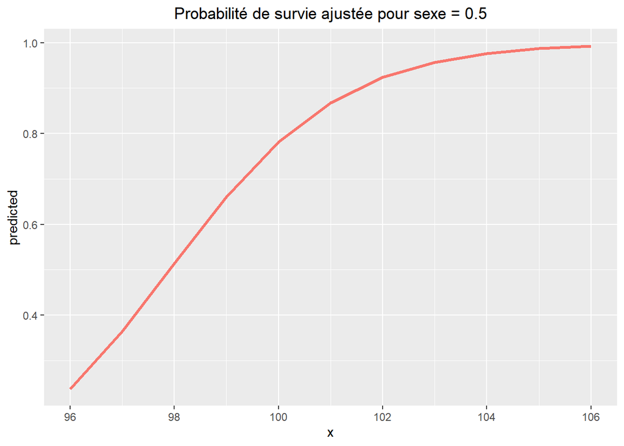

```r
plot.masse.sexe.test <- ggplot()+
geom_line(data = predictions.masse.sexe.test,
          aes(x = x, y = predicted, color = group),
          show.legend = FALSE,
          linewidth=1.1)+
labs(title = "Probabilité de survie ajustée pour sexe = 0.5")+
theme(plot.title = element_text(hjust = 0.5))

plot.masse.sexe.test
```

Dans notre cas, par contre, il serait plus intéressant de pouvour visualiser cette différence.

Pour cela, il faut inclure la variable `sexe` dans la fonction `ggpredict`:

```r
predictions.masse.sexe <- ggpredict(modele.masse.sexe, c("masse","sex"))
```

```
## Data were 'prettified'. Consider using `terms="masse [all]"` to get
##   smooth plots.
```

```r
predictions.masse.sexe
```

```
## # Predicted probabilities of survie
##
## # sex = 0
##
## masse | Predicted |       95% CI
## --------------------------------
##    96 |      0.14 | [0.01, 0.75]
##    98 |      0.35 | [0.07, 0.80]
##    99 |      0.50 | [0.17, 0.84]
##   101 |      0.77 | [0.52, 0.91]
##   103 |      0.92 | [0.73, 0.98]
##   106 |      0.99 | [0.84, 1.00]
##
## # sex = 1
##
## masse | Predicted |       95% CI
## --------------------------------
##    96 |      0.38 | [0.07, 0.83]
##    98 |      0.67 | [0.31, 0.90]
##    99 |      0.79 | [0.48, 0.94]
##   101 |      0.93 | [0.70, 0.99]
##   103 |      0.98 | [0.79, 1.00]
##   106 |      1.00 | [0.86, 1.00]
```

```
##
## Not all rows are shown in the ouput. Use `print(..., n = Inf)` to show
##   all rows.
```

Cette fois-ci, nous obtenons deux tables de valeurs prédites - une pour `sex = 0` (femelles) et une pour `sex = 1` (mâles).

Dans le précédent modèle, nous avions défini l’`aes(color=group)`, pour colorer notre ligne. La notion de groupe était plus abstraite, car il n’y avait en réalité qu’un seul groupe. Par contre, ici, dans `plot.masse.sexe`, nous en avons deux - les femelles et les mâles. Donc, quand on assigne `color` aux `group`, nous colorons les deux groupes de couleurs différentes:

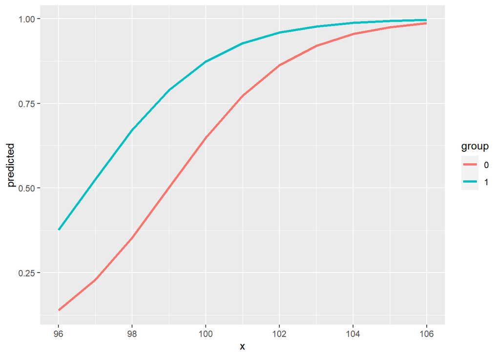

```r
plot.masse.sexe <- ggplot()+
geom_line(data = predictions.masse.sexe,
          aes(x = x, y = predicted, color = group),
          show.legend = TRUE,
          linewidth=1.1)

plot.masse.sexe
```

On doit ajouter nos intervalles de confiance:

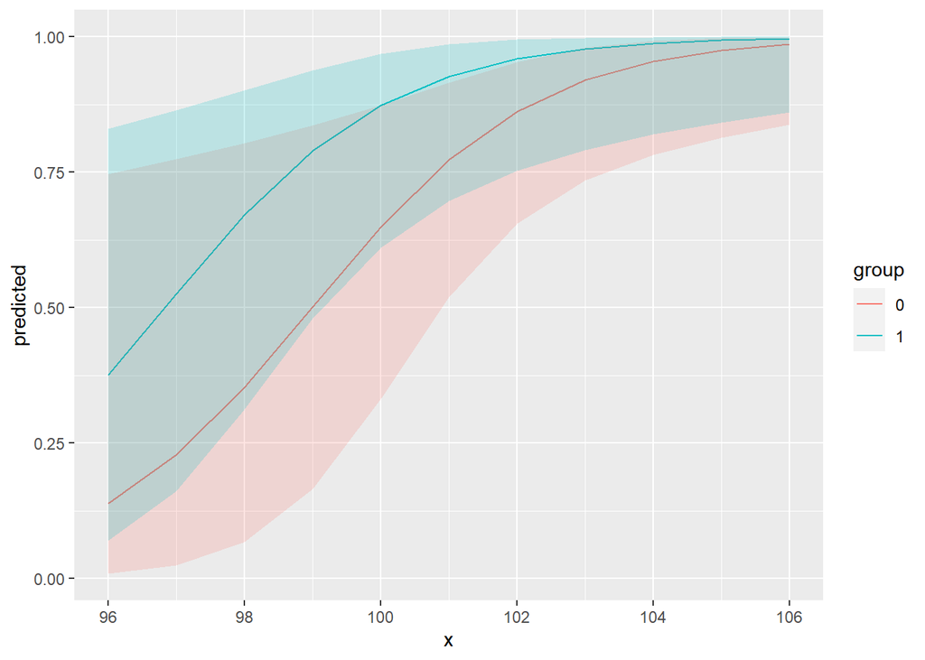

```r
plot.masse.sexe <- ggplot()+
geom_line(data = predictions.masse.sexe,
          aes(x = x, y = predicted, color = group),
          show.legend = TRUE)+
geom_ribbon(data = predictions.masse.sexe,
            show.legend = FALSE,
            aes(x = x, y = predicted, fill = group, ymin = conf.low, ymax = conf.high),
            alpha = 0.2)

plot.masse.sexe
```

La légende doit aussi être modifiée. `scale_color_manual` traite la couleur du trait formé par `geom_line()`, et `scale_fill_manual`, le remplissage du ruban `geom_ribbon`. En même temps, avec ces mêmes fonctions, on peut spécifier le titre de la légende (on n’écrit pas “Légende”!), le nom des groupes (la variable `sex` est codée 0 / 1, donc on doit ajouter manuellement ces noms). On peut aussi changer les couleurs.

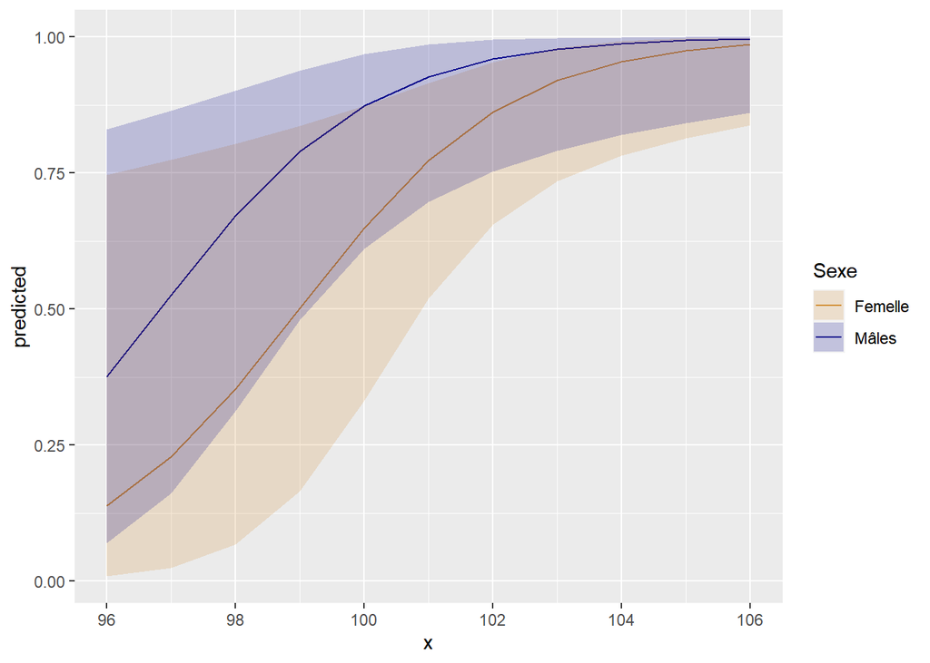

```r
plot.masse.sexe <- ggplot()+
geom_line(data = predictions.masse.sexe,
          aes(x = x, y = predicted, color = group),
          show.legend = TRUE)+
geom_ribbon(data = predictions.masse.sexe,
            show.legend = TRUE,
            aes(x = x, y = predicted, fill = group, ymin = conf.low, ymax = conf.high),
            alpha = 0.2)+
scale_color_manual(name = "Sexe",
                   labels = c("Femelle", "Mâles"),
                   values = c("0" = "#D28D32", "1" = "darkblue"))+
scale_fill_manual(name = "Sexe",
                  labels = c("Femelle", "Mâles"),
                  values = c("0" = "#D28D32", "1" = "darkblue"))

plot.masse.sexe
```

Il est important que les noms et les `aes()` soient constants pour chaque ligne de notre figure `ggplot()`. Sinon, des légendes supplémentaires sont créées:

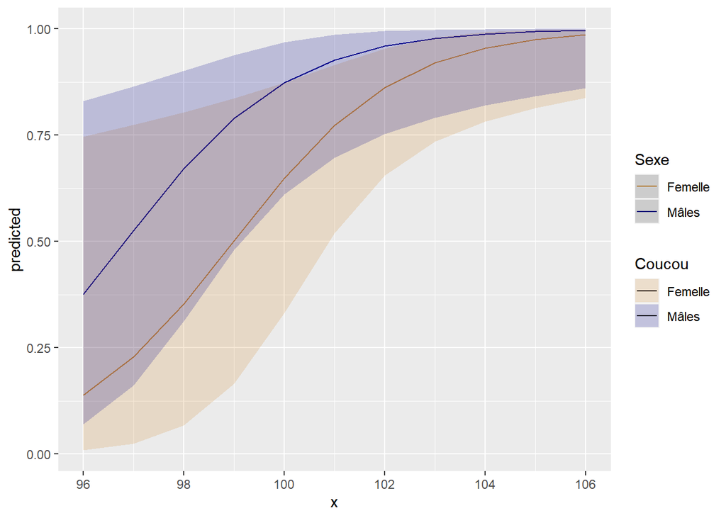

```r
plot.masse.sexe <- ggplot()+
geom_line(data = predictions.masse.sexe,
          aes(x = x, y = predicted, color = group),
          show.legend = TRUE)+
geom_ribbon(data = predictions.masse.sexe,
            show.legend = TRUE,
            aes(x = x, y = predicted, fill = group, ymin = conf.low, ymax = conf.high),
            alpha = 0.2)+
scale_color_manual(name = "Sexe",
                   labels = c("Femelle", "Mâles"),
                   values = c("0" = "#D28D32", "1" = "darkblue"))+
scale_fill_manual(name = "Coucou",
                  labels = c("Femelle", "Mâles"),
                  values = c("0" = "#D28D32", "1" = "darkblue"))

plot.masse.sexe
```

On peut ajouter les éléments graphiques que nous avions codés pour la figure de notre premier modèle: `geom_line(linewidth=1.1)` `labs()` `theme_bw()` `theme()` `scale_y_continuous(labels = scales::percent, limits = c(-0.02, 1.02))`

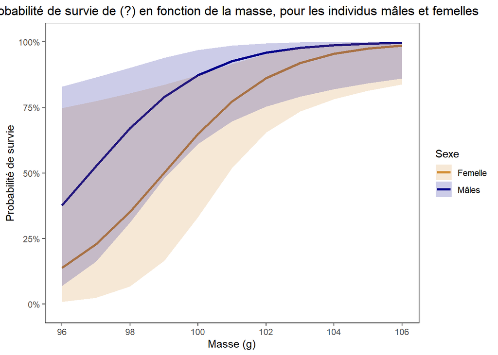

```r
plot.masse.sexe <- ggplot()+
geom_line(data = predictions.masse.sexe, aes(x=x, y = predicted, color = group),
          show.legend = TRUE,
          linewidth = 1.1)+
geom_ribbon(data = predictions.masse.sexe,
            show.legend = TRUE,
            aes(x = x, y = predicted, fill = group, ymin = conf.low, ymax = conf.high),
            alpha = 0.2)+
scale_color_manual(name = "Sexe",
                   labels = c("Femelle", "Mâles"),
                   values = c("0" = "#D28D32", "1" = "darkblue"))+
scale_fill_manual(name = "Sexe",
                  labels = c("Femelle", "Mâles"),
                  values = c("0" = "#D28D32", "1" = "darkblue"))+
labs(x = "Masse (g)",
     y = "Probabilité de survie",
     title = "Probabilité de survie de (?) en fonction de la masse, pour les individus mâles et femelles")+
theme_bw()+
theme(panel.grid.major = element_blank(),
      panel.grid.minor = element_blank(),
      plot.title = element_text(hjust = 0.5))+
scale_y_continuous(labels = scales::percent,
                   limits = c(-0.02, 1.02))

plot.masse.sexe
```

Le titre est devenu plus long et pourrait déborder de la figure (cela dépendra des paramètres choisis au moment d’exporter la figure). On peut utiliser `\n` pour indiquer précisément l’endroit où couper notre texte:

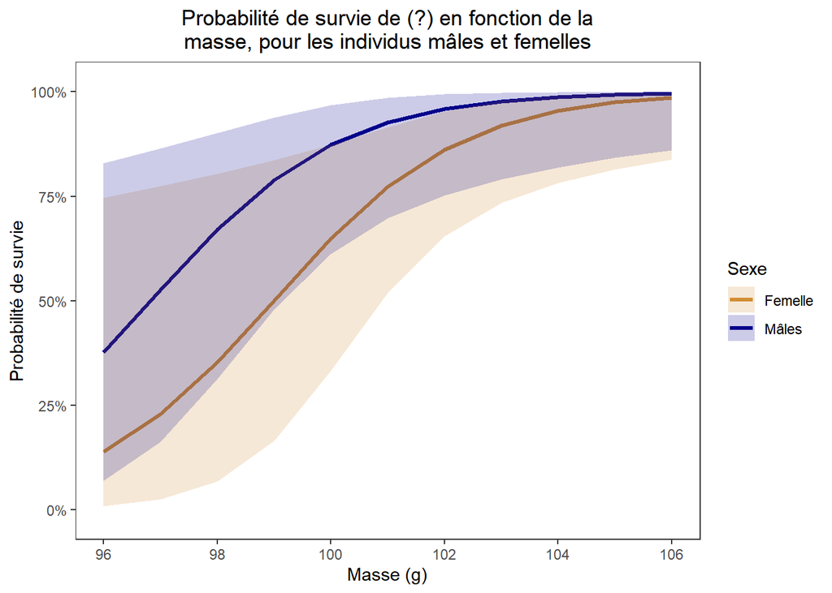

```r
plot.masse.sexe <- ggplot()+
geom_line(data = predictions.masse.sexe,
          aes(x = x, y = predicted, color = group),
          show.legend = TRUE,
          linewidth = 1.1)+
geom_ribbon(data = predictions.masse.sexe,
            show.legend = TRUE,
            aes(x = x, y = predicted, fill = group, ymin = conf.low, ymax = conf.high),
            alpha = 0.2)+
scale_color_manual(name = "Sexe",
                   labels = c("Femelle", "Mâles"),
                   values = c("0" = "#D28D32", "1" = "darkblue"))+
scale_fill_manual(name = "Sexe",
                  labels = c("Femelle", "Mâles"),
                  values = c("0" = "#D28D32", "1" = "darkblue"))+
labs(x = "Masse (g)",
     y = "Probabilité de survie",
     title = "Probabilité de survie de (?) en fonction de la\nmasse, pour les individus mâles et femelles")+
theme_bw()+
theme(panel.grid.major = element_blank(),
      panel.grid.minor = element_blank(),
      plot.title = element_text(hjust = 0.5))+
scale_y_continuous(labels = scales::percent,
                   limits = c(-0.02, 1.02))

plot.masse.sexe
```

Je dois faire une dernière étape pour afficher correctement les données brutes.

```r
surv$sex<-as.factor(surv$sex)
```

Sinon, il traite `sex` comme étant une variable continue (ce qu’elle est), et on ne peut pas appliquer les paramètres graphiques correctement!